## DV2 – HW2

*CEU BA*

*Ersan Kucukoglu - 1904225*

18 January, 2022

### 0. Load the nycflights13 package and check what kind of datasets exist in the package, then create a copy of flights dataset into a data.table object, called flight_data.

```r
#load the nycflights13 package
library(nycflights13)
#check datasets
data(package='nycflights13')
#flights dataset
library(data.table)
flight_data <- as.data.table(nycflights13::flights)
```

### 1. Which destination had the lowest avg arrival delay from LGA with minimum 100 flight to that destination?

```
##    destination avg_arr_delay no_flights
## 1:         DAY     -4.947368        391
```

### 2. Which destination’s flights were the most on time (avg arrival delay closest to zero) from LGA with minimum 100 flight to that destination?

```
##    destination avg_arr_delay no_flights
## 1:         MIA    -0.0657664       5781
```

### 3. Who is the manufacturer of the plane, which flights the most to CHS destination?

```
##    tailnum   manufacturer no_flight
## 1:  N713EV BOMBARDIER INC        22
```

### 4. Which airline (carrier) flow the most by distance?

```
##    carrier total_distance
## 1:      UA       89705524
```

### 5. Plot the monthly number of flights with 20+ mins arrival delay!

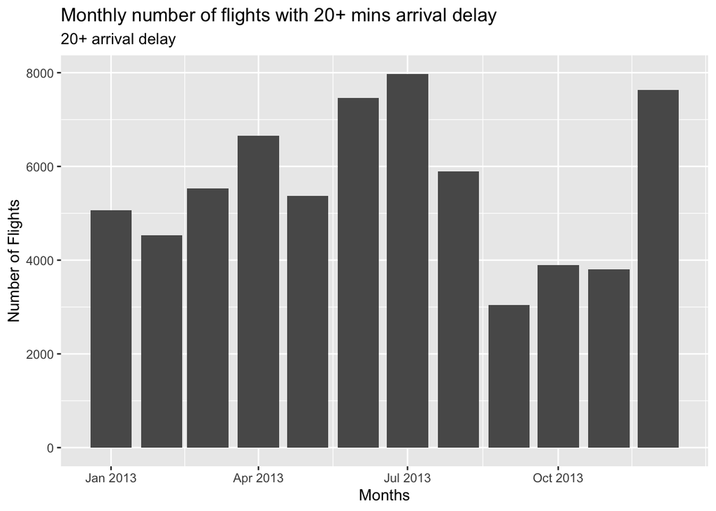

### 6. Plot the departure delay of flights going to IAH and the related day’s wind speed on a scaterplot! Is there any association between the two variables? Try adding a linear model.

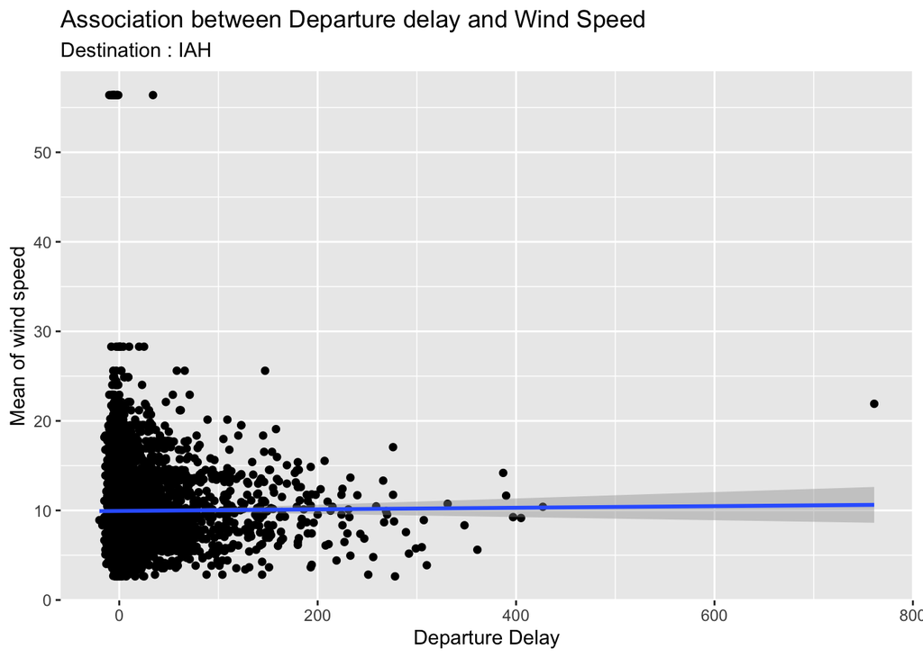

### 7. Plot the airports as per their geolocation on a world map, by mapping the number flights going to that destionation to the size of the symbol!

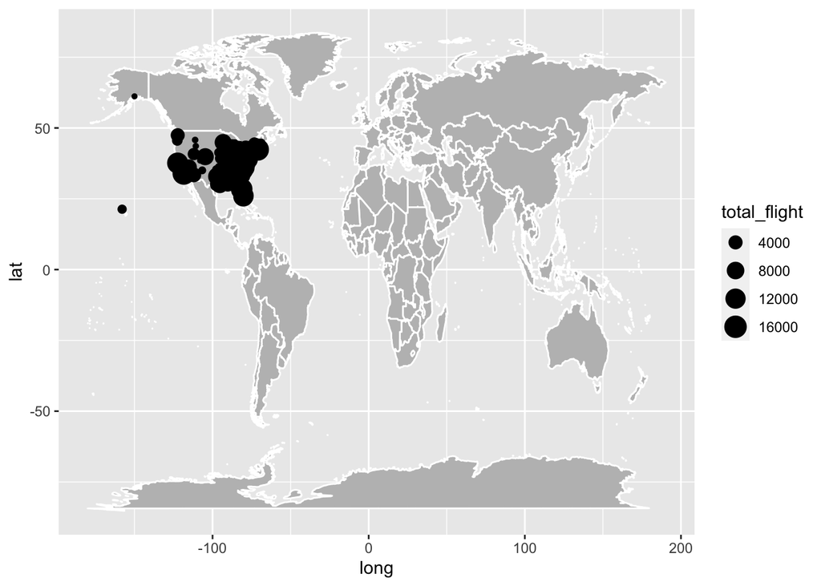